# Visualization

Amaie

5/10/2022

การสร้างภาพข้อมูลหรือ Data Visualization ช่วยให้เราเข้าใจชุดข้อมูลที่มีความซับซ้อนได้ง่ายขึ้นและทำให้เราตัดสินใจในการจัดการกับข้อมูลเร็วขึ้น ซึ่ง Data Visualization สามารถทำได้ทั้งก่อนและหลังการวิเคราะห์เชิงสถิติ

การสร้างภาพข้อมูลใน `R` สามารถทำได้จากหลากหลาย package ซึ่งใน tutorial นี้เราจะใช้ package `ggplot2` ซึ่งเป็น package ที่ช่วยให้เราสามารถสร้างกราฟิคได้หลากหลาย และสามารถปรับแต่งรูปแบบต่าง ๆ ได้ในแบบที่ต้องการ

```r
#load packages
library(ggplot2)
library(psych)
library(Rmisc)
```

## Mtcars data

ใน tutorial นี้เราจะใช้ข้อมูลที่มีอยู่แล้วใน package `ggplot2` ชื่อว่า `mtcars` ในการสร้างกราฟฟิค  
หลังจาก import `mtcars` ลงมาแล้ว เราสามารถเซ็ตค่าตัวแปรได้ตามนี้

```r
data("mtcars")

mtcars$vs <- factor(mtcars$vs, labels = c("V", "S"))
mtcars$am <- factor(mtcars$am, labels = c("automatic", "manual"))
mtcars$cyl  <- as.factor(mtcars$cyl)
mtcars$gear <- as.factor(mtcars$gear)
mtcars$carb <- as.factor(mtcars$carb)

psych::describe(mtcars)
```

```
##       vars  n   mean     sd median trimmed    mad   min    max  range  skew
## mpg      1 32  20.09   6.03  19.20   19.70   5.41 10.40  33.90  23.50  0.61
## cyl*     2 32   2.09   0.89   2.00    2.12   1.48  1.00   3.00   2.00 -0.17
## disp     3 32 230.72 123.94 196.30  222.52 140.48 71.10 472.00 400.90  0.38
## hp       4 32 146.69  68.56 123.00  141.19  77.10 52.00 335.00 283.00  0.73
## drat     5 32   3.60   0.53   3.70    3.58   0.70  2.76   4.93   2.17  0.27
## wt       6 32   3.22   0.98   3.33    3.15   0.77  1.51   5.42   3.91  0.42
## qsec     7 32  17.85   1.79  17.71   17.83   1.42 14.50  22.90   8.40  0.37
## vs*      8 32   1.44   0.50   1.00    1.42   0.00  1.00   2.00   1.00  0.24
## am*      9 32   1.41   0.50   1.00    1.38   0.00  1.00   2.00   1.00  0.36
## gear*   10 32   1.69   0.74   2.00    1.62   1.48  1.00   3.00   2.00  0.53
## carb*   11 32   2.72   1.37   2.00    2.65   1.48  1.00   6.00   5.00  0.35
##       kurtosis    se
## mpg      -0.37  1.07
## cyl*     -1.76  0.16
## disp     -1.21 21.91
## hp       -0.14 12.12
## drat     -0.71  0.09
## wt       -0.02  0.17
## qsec      0.34  0.32
## vs*      -2.00  0.09
## am*      -1.92  0.09
## gear*    -1.07  0.13
## carb*    -0.95  0.24
```

## Ggplot2 Package

Ggplot2 เป็น package ในรูปแบบของ Grammar of Graphic ที่ความยืดหยุ่น ซึ่งในการเขียนคำสั่งของ `ggplot2` นั้น จะมีลักษณะเป็นการเรียงคำสั่งในแต่ละขั้น  
โดยปกติแล้ว คำสั่งที่ใช้งานพื้นฐานจะประกอบไปด้วย

- `data` - การเรียกข้อมูลที่ใช้งาน
- `aesthetic mappings` - การเลือกตัวแปรที่จะปรากฎอยู่ในกราฟ
- `geometric objects` - การเลือกวิธีการสร้างกราฟฟิค
- `Customizing` เช่น การใส่ชื่อ เลือกธีม หรือลงสีให้กราฟ

นอกจากนี้ยังมีคำสั่งอื่น ๆ ที่มีความซับซ้อนมากขึ้น หากเราเริ่มคุ้นเคยกับคำสั่งพื้นฐานแล้ว เราสามารถศึกษาเพิ่มเติมให้กราฟฟิคมีความสวยงามและตรงตามความต้องการของเรามากขึ้นได้

## การสร้างกราฟ

ก่อนที่เราจะสร้างกราฟ เราควรสังเกตตัวแปรที่เราต้องการนำมาสร้างว่าเป็นตัวแปรลักษณะใด โดยสามารถใช้คำสั่ง `str()`

```r
str(mtcars)
```

```
## 'data.frame':    32 obs. of  11 variables:
##  $ mpg : num  21 21 22.8 21.4 18.7 18.1 14.3 24.4 22.8 19.2 ...
##  $ cyl : Factor w/ 3 levels "4","6","8": 2 2 1 2 3 2 3 1 1 2 ...
##  $ disp: num  160 160 108 258 360 ...
##  $ hp  : num  110 110 93 110 175 105 245 62 95 123 ...
##  $ drat: num  3.9 3.9 3.85 3.08 3.15 2.76 3.21 3.69 3.92 3.92 ...
##  $ wt  : num  2.62 2.88 2.32 3.21 3.44 ...
##  $ qsec: num  16.5 17 18.6 19.4 17 ...
##  $ vs  : Factor w/ 2 levels "V","S": 1 1 2 2 1 2 1 2 2 2 ...
##  $ am  : Factor w/ 2 levels "automatic","manual": 2 2 2 1 1 1 1 1 1 1 ...
##  $ gear: Factor w/ 3 levels "3","4","5": 2 2 2 1 1 1 1 2 2 2 ...
##  $ carb: Factor w/ 6 levels "1","2","3","4",..: 4 4 1 1 2 1 4 2 2 4 ...
```

หลักการในการสร้างกราฟฟิคคือ การสังเกตจำนวนตัวแปรและลักษณะของตัวแปรในแกน x และ y โดยลักษณะของตัวแปรนี้จะเป็นการคัดรูปแบบกราฟของเรา  
ใน tutorial นี้เราจะเรียนรู้สร้าง boxplot, bar graph และ line graph ค่ะ

### การสร้าง boxplot

ในการสร้าง boxplot (หรือกราฟลักษณะอื่น ๆ) เราจะเริ่มกันที่การสร้างคำสั่งพื้นฐาน คือ `data` และ `aesthetic mappings`  
โดยคำสั่งทั่วไปคือ `ggplot(data = ชื่อไฟล์, aes(x = ตัวแปรแกน x, y = ตัวแปรแกน y)`

คำสั่ง `aes()` สามารถเซ็ตค่าอื่น ๆ ได้ เช่น

- ตำแหน่งของตัวแปร (`x =` และ `y =` )
- สี: โดย `color=` เป็นสีเส้นขอบ และ `fill=` เป็นสีด้านใน
- `shape =` รูปร่างของจุดข้อมูล และ `size =`ขนาดของจุดข้อมูล

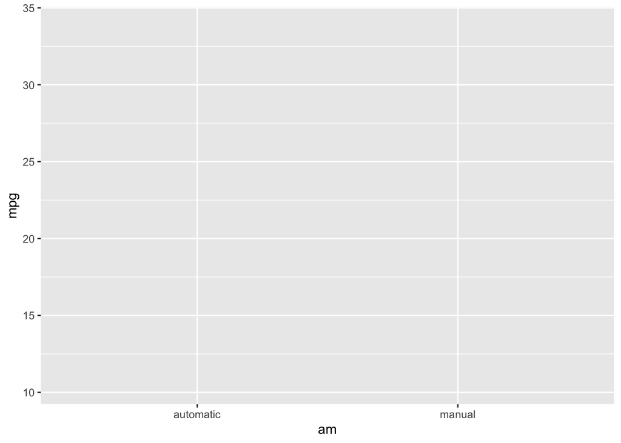

```r
ggplot(data = mtcars, aes(x = am, y = mpg))
```

ถ้าเรา `run` คำสั่งข้างต้น เราจะพบว่า กราฟฟิคมีเพียง `background` (หรือ `coordinate system`) และชื่อตัวแปรของเราเท่านั้น ดังนั้นเราจึงจำเป็นต้องเขียนคำสั่งว่าเราต้องการให้กราฟออกมาเป็นรูปแบบใด (สามารถเข้าไปดูรูปแบบทั้งหมดได้ที่ `help.search("geom_", package = "ggplot2")`

สำหรับการสร้าง boxplot เราจะใช้คำสั่ง `geom_boxplot()` เพื่อเซ็ตค่า `geometric objects`

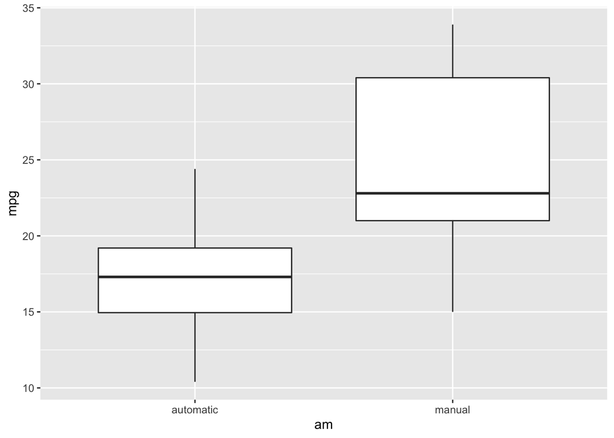

```r
ggplot(data = mtcars, aes(x = am, y = mpg)) +
  geom_boxplot()
```

จะเห็นว่ากราฟ boxplot ที่สร้างขึ้นมามีเพียงตัวแปร x และ y หากเราต้องการจัดกลุ่มตัวแปร เราสามารถใช้คำสั่ง `fill = ตัวแปรจัดกลุ่ม` ใน `aesthetic mapping` เพื่อให้มีการจัดกลุ่มของตัวแปรในกราฟ

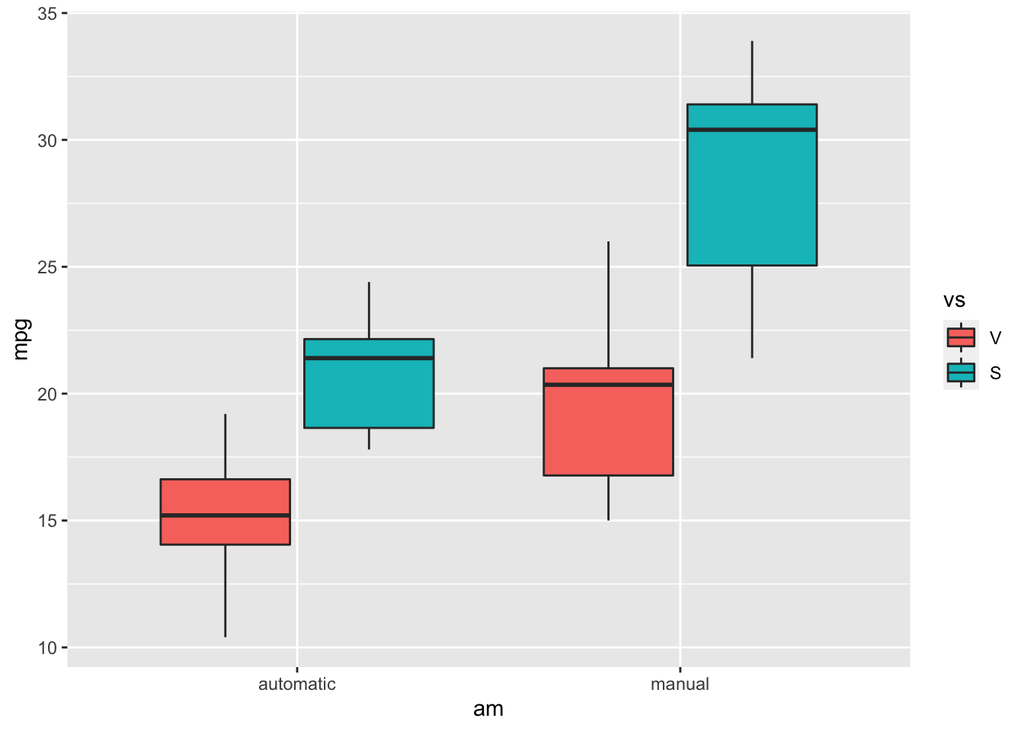

```r
ggplot(data = mtcars, aes(x = am, y = mpg, fill = vs)) +
  geom_boxplot()
```

หากเราต้องการให้กราฟมีสีสันและชื่อแกนตามที่เราต้องการ เราสามารถเขียนคำสั่งต่อจาก คำสั่ง geometric ได้

ตัวอย่างคำสั่งอื่น ๆ ในการปรับแต่งกราฟ

- **เพิ่มลักษณะกราฟฟิค:**
  - หากเราอยากให้ `ggplot2` สร้างจุดข้อมูลในกราฟของเรา เราสามารถสั่งคำสั่ง `geom_jitter()` หลังจาก geometric objects หลักของเราได้
- **ตกแต่งกราฟ:**
  - ใช้คำสั่ง `alpha = ค่าโปรงใส` เพื่อเพิ่มความโปร่งใสของกราฟ
  - ใช้คำสั่ง `width = ค่าความกว้างของกราฟ` ในการกำหนดความกว้างของกราฟ
- **เพิ่มชื่อ:**
  - **แกน x และ y**: ใช้คำสั่ง `xlab = "ชื่อแกน x"` และ `ylab = "ชื่อแกน y"`
  - **ชื่อหัวกราฟ:** ใช้คำสั่ง `ggtitle("ชื่อหัวกราฟ")`
- **เลือกใช้ theme:**
  - **ธีมของกราฟ:** ใช้คำสั่ง `theme_` ในการเลือกใช้ theme โดย คำสั่ง `theme_classic` จะใกล้เคียงกับ APA
  - **สีของกราฟ:**
    - เลือกจาก palette ที่มีชุดคำสั่งสี
      - สีเส้นขอบ: `scale_color_brewer(palette = "ชื่อ palette ที่ต้องการ")`
      - สีช่องในกล่องหรือคอลัมน์: `scale_fill_brewer(palette = "ชื่อ palette ที่ต้องการ")`
    - เลือกสีเอง
      - สีเส้นขอบ: `scale_color_manual(values=c("สีที่1", "สีที่2", "สีที่3"))`
      - สีช่องในกลุ่มหรือคอลัมน์: `scale_fill_manual(values=c("สีที่1", "สีที่2", "สีที่3"))`

*Note*: หากเลือกสีเอง จำนวนสีต้องเท่ากับจำนวนกลุ่มตัวแปรที่ต้องการจะให้มีสี

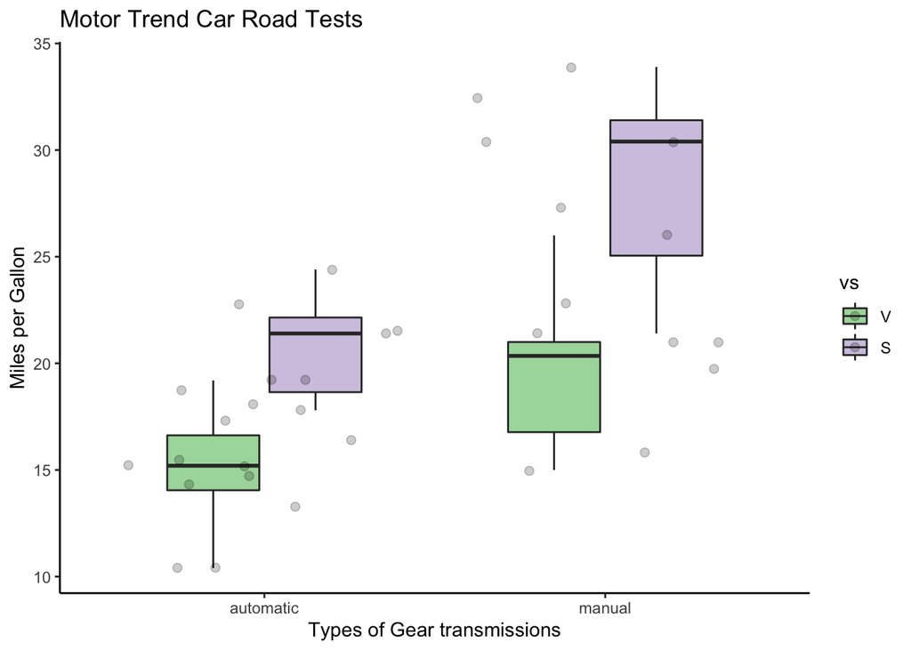

```r
ggplot(data = mtcars, aes(x = am, y = mpg, fill = vs)) +
  geom_boxplot(alpha = 0.7, width = 0.6) +
  geom_jitter(alpha = 0.2, size = 2) +
  xlab("Types of Gear transmissions") +
  ylab("Miles per Gallon") +
  ggtitle("Motor Trend Car Road Tests") +
  theme_classic() +
  scale_color_brewer(palette="Accent") +
  scale_fill_brewer(palette="Accent")
```

จะเห็นได้ว่าสีของกล่องข้อมูลเปลี่ยนไปตามที่เราตั้งค่าไว้ และมีการแสดงของจุดข้อมูลที่มาจากชุดคำสั่ง `geom_jitter()` โดยมีความโปร่งใสของจุดข้อมูลให้เห็นในกราฟ

### การสร้าง Bar Graph

การสร้าง Bar Graph เหมาะสมกับตัวแปรต้นที่มีลักษณะเป็นกลุ่ม (discrete variable) ดังนั้นโครงสร้างของชุดคำสั่งจะคล้ายคลึงกับการสร้าง boxplot

เราสามารถสร้าง bar graph ได้ 2 วิธีคือ

- `geom_bar()` จะมีคำสั่งพื้นฐานโดยมีความสูงของกราฟจากสัดส่วนของ n ในข้อมูล
- `geom_col()` จะมีคำสั่งพื้นฐานโดยมีความสูงของกราฟเป็นค่าของข้อมูลนั้น ๆ คำสั่งนี้จะเหมาะสมกับข้อมูลที่ผ่านการหาค่าสถิติเชิงพรรณามาแล้ว (เช่นค่า *n*, *mean*, *sd*, *se*) และนำไปใช้งานได้สะดวกกว่าเมื่อต้องการสร้าง `error_bar`

ดังนั้น หากต้องการสร้าง bar graph อย่างง่าย เราสามารถใช้คำสั่ง `geom_bar()` ได้ โดยเพิ่มคำสั่ง `stat = "summary"` เมื่อต้องการค่าเฉลี่ย (mean) หรือ `stat = "identity"` เมื่อต้องการค่าผลรวม (sum)

นอกจากนี้แล้ว การสร้าง bar graph ยังสามารถเลือกการวางตัวของกราฟได้ โดยใช้คำสั่ง `position =`โดยค่าพื้นฐานของ `geom_bar()` คือ `position = "stack"` โดยจะเป็นการต่อกันของข้อมูลในแต่ละกลุ่ม ถ้าต้องการให้กราฟอยู่แยกกัน เราจะใช้คำสั่ง `position = "dodge"` หรือ `position = position_dodge(ค่าความห่าง)`

```
##
##  Descriptive statistics by group
## am: automatic
## vs: V
##    vars  n  mean   sd median trimmed mad  min  max range  skew kurtosis  se
## X1    1 12 15.05 2.77   15.2    15.1 2.3 10.4 19.2   8.8 -0.28    -0.96 0.8
## ------------------------------------------------------------
## am: manual
## vs: V
##    vars n  mean   sd median trimmed  mad min max range skew kurtosis   se
## X1    1 6 19.75 4.01  20.35   19.75 3.85  15  26    11 0.21    -1.53 1.64
## ------------------------------------------------------------
## am: automatic
## vs: S
##    vars n  mean   sd median trimmed  mad  min  max range skew kurtosis   se
## X1    1 7 20.74 2.47   21.4   20.74 3.26 17.8 24.4   6.6  0.1    -1.75 0.93
## ------------------------------------------------------------
## am: manual
## vs: S
##    vars n  mean   sd median trimmed mad  min  max range  skew kurtosis  se
## X1    1 7 28.37 4.76   30.4   28.37 4.6 21.4 33.9  12.5 -0.35    -1.73 1.8
```

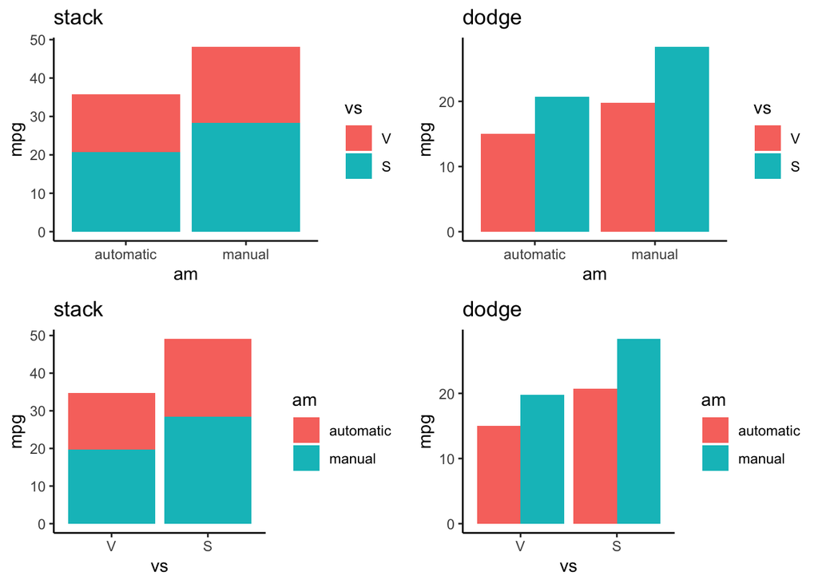

```r
# x axis is am
#  stack
stack <- ggplot(data = mtcars, aes(x = am, y = mpg, fill = vs)) +
         geom_bar(stat = "summary") +
         ggtitle("stack") +
         theme_classic()
#  dodge
dodge <- ggplot(data = mtcars, aes(x = am, y = mpg, fill = vs)) +
         geom_bar(stat = "summary", position = position_dodge(0.9)) +
         ggtitle("dodge") +
         theme_classic()
#x axis is vs
#  stack
stack2 <- ggplot(data = mtcars, aes(x = vs, y = mpg, fill = am)) +
         geom_bar(stat = "summary") +
         ggtitle("stack") +
         theme_classic()
#  dodge
dodge2 <- ggplot(data = mtcars, aes(x = vs, y = mpg, fill = am)) +
         geom_bar(stat = "summary", position = position_dodge(0.9)) +
         ggtitle("dodge") +
         theme_classic()

describeBy(mpg ~ am * vs, data = mtcars)
```

### การสร้างกราฟที่มี Error Bar

ในการสร้างกราฟแบบ bar graph และ line graph เราสามารถที่จะแสดงผลความคลาดเคลื่อนข้อมูลโดยเพิ่มคำสั่ง `geom_errorbar()` โดยเราสามารถหาค่า *sd*, *se*, หรือ *ci* จากข้อมูลที่เรามีก่อนการสร้าง Error Bar โดยใช้คำสั่ง `summarySE()` จาก package `Rmisc`โดยใช้คำสั่ง

`summarySE(ชื่อไฟล์, measurevar = "ชื่อตัวแปรที่ต้องการหาค่ามาตรฐาน", groupvars = c("ชื่อกลุ่ม 1", "ชื่อกลุ่ม 2"))`

```r
library(Rmisc)

sum <- summarySE(mtcars, measurevar="mpg", groupvars=c("am","vs"))
sum
```

```
##          am vs  N      mpg       sd        se       ci
## 1 automatic  V 12 15.05000 2.774396 0.8008991 1.762767
## 2 automatic  S  7 20.74286 2.471071 0.9339769 2.285359
## 3    manual  V  6 19.75000 4.008865 1.6366124 4.207046
## 4    manual  S  7 28.37143 4.757701 1.7982418 4.400139
```

เมื่อได้ค่าความคลาดเคลื่อนออกมาแล้ว เราจะสร้างกราฟจาก object ที่มาจาก `summarySE()` นี้

โดยในการสร้าง line graph เราจะใช้คำสั่ง `geom_point()` และ `geom_line()` โดย `geom_point()` จะเป็นการกำหนดให้กราฟมีจุดที่เป็นค่า mean และ `geom_line()`จะเป็นการใส่เส้นกราฟ ซึ่งเราสามารถเซ็ตให้กราฟมีการแยกกลุ่มตามที่เรากำหนดโดยใส่ `aes(group = ตัวแปรจัดกลุ่ม)`

จากนั้น เพิ่มคำสั่ง `geom_errorbar()` ในการสร้าง error bar โดยใช้คำสั่ง `aes(ymin = ชื่อตัวแปรค่า mean - ci, ymax = ชื่อตัวแปรค่า mean + ci)` (*Note*: เราสามารถใช้ค่า *sd* หรือ *se* ในการสร้าง error bar ได้โดยการเปลี่ยน `ci` เป็น `sd` หรือ `se`)

หากกราฟที่ปรากฎออกมามีค่าแกน x และ y ที่ไม่สมดุล เราสามารถใช้คำสั่ง `xlim()` หรือ `ylim()` เพื่อปรับแก้สเกลให้เหมาะสมได้

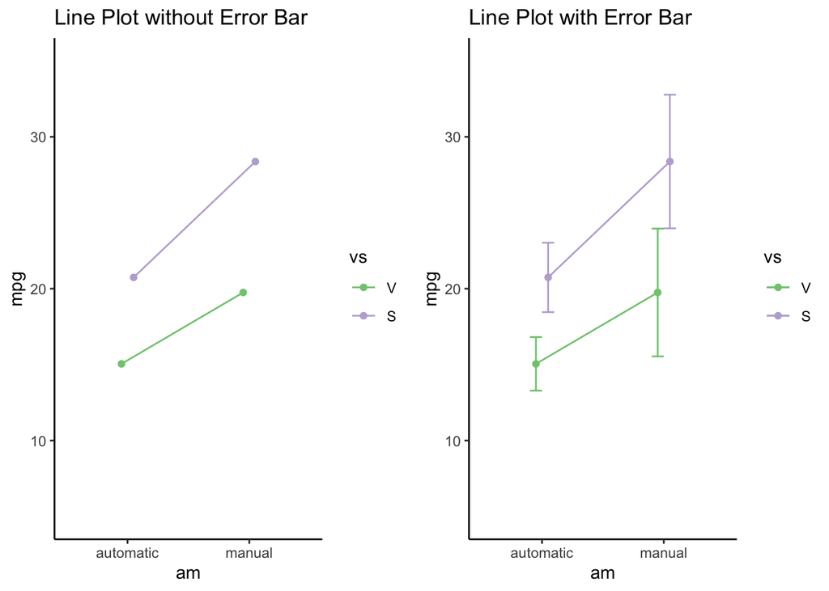

```r
#only plot
line.plot <- ggplot(sum, aes(x = am, y = mpg, color = vs)) +
             geom_point(position = position_dodge(.2)) +
             geom_line(aes(group = vs), position = position_dodge(.2)) +
             ylim(5, 35) +
             ggtitle("Line Plot without Error Bar") +
             theme_classic() +
             scale_color_brewer(palette="Accent")

#with error

line.error <- ggplot(sum, aes(x = am, y = mpg, color = vs)) +
             geom_point(position = position_dodge(.2)) +
             geom_line(aes(group = vs), position = position_dodge(.2)) +
             geom_errorbar(aes(ymin=mpg-ci, ymax=mpg+ci), width=.2,
                           position=position_dodge(.2)) +
             ylim(5, 35) +
             ggtitle("Line Plot with Error Bar") +
             theme_classic() +
             scale_color_brewer(palette="Accent")
```

นอกจากนี้ การสร้าง error bar ด้วยคำสั่ง `geom_errorbar()` ยังสามารถนำไปประยุกต์กับ bar graph ได้เช่นกัน แต่ในกรณีรการสร้าง bar graph จากข้อมูลที่หาค่าสถิติจากคำสั่ง `summarySE()` มาแล้วนั้น สังเกตว่าจะมีค่า mean เฉลี่ยแต่ละกลุ่ม (และค่าความคลาดเคลื่อนอื่น ๆ) เท่านั้น ดังนั้นในกรณีนี้เราจะใช้คำสั่ง `geom_col()` ในการสร้าง bar graph

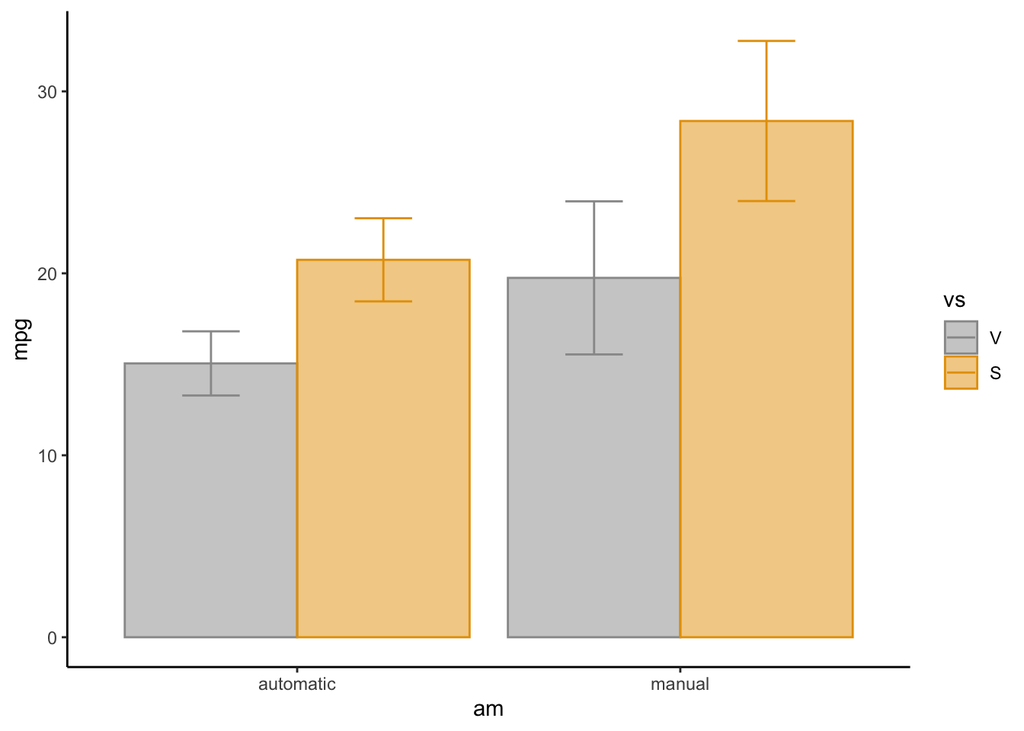

```r
bar.error <- ggplot(sum, aes(x = am, y = mpg, color = vs)) +
             geom_col(aes(fill = vs), alpha = .5, position = position_dodge(.9)) +
             geom_errorbar(aes(ymin=mpg-ci, ymax=mpg+ci), width = .3,
                           position = position_dodge(.9)) +
             theme_classic() +
             scale_color_manual(values=c("#999999", "#E69F00", "#56B4E9")) +
             scale_fill_manual(values=c("#999999", "#E69F00", "#56B4E9"))

bar.error
```